# Gene Expression of Cancer in RNA-Seq, Clustering, and Classification

Andrea Debeni, Beksultan Tuleev

## **Information about data**

### The project

Cancer is one of the most studied diseases worldwide: the history of medicine is studded with projects and researches that aim to find explanations to the causes of different forms of cancer, and the more technology develops, the more tools are provided to the scientific community to address this extremely complex matter.  
In this context acts The Cancer Genome (TCGA) Research Network, which analyzes and profiles a large number of human tumors to discover molecular aberrations at the DNA, RNA, protein, and epigenetic levels. The resulting data can be used to find commonalities, differences, and emergent themes across tumor lineages. With this focus, the Pan-Cancer initiative compares the first 12 tumor types profiled by TCGA: the analysis of the molecular aberrations can result in improved comprehension of the phenomena, hence therapies effective in certain cancer types could be extended to others presenting a similar genomic profile.

### The dataset

The dataset is part of Ribonucleic Acid Sequence (RNA-seq) from the Pancreatic Cancer Action Network (PanCAN). Dataset is a random gene expression extraction from patients who have different types of tumor cancer. Among the 12 analyzed by the PanCAN project, five of them were included in the dataset: The Cancer Genome Atlas Breast Invasive Carcinoma (TCGA-BRCA or BRCA), The Cancer Genome Atlas Kidney Renal Clear Cell Carcinoma (TCGA-KIRC or KIRC), The Cancer Genome Atlas Colon Adenocarcinoma (TCGA-COAD or COAD), The Cancer Genome Atlas Lung Adenocarcinoma (TCGA-LUAD or LUAD), and The Cancer Genome Atlas Prostate Adenocarcinoma (TCGA-PRAD or PRAD).

Samples (instances) are stored row-wise. Variables (attributes) of each sample are RNA-Seq gene expression levels measured by illumina HiSeq platform. RNA-Seq is a sequencing technique that aims to reveal the presence and quantity of RNA in a biological sample at a given moment, analyzing the changing cellular transcriptome. Gene expression is quantified by counting the number of reads that are mapped to each locus in the transcriptome assembly step, namely the first step of the process.

Sources: https://archive.ics.uci.edu/ml/datasets/gene+expression+cancer+RNA-Seq

Weinstein, John N., et al. *The cancer genome atlas pan-cancer analysis project*, Nature genetics 45.10 (2013): 1113-1120, DOI: https://dx.doi.org/10.1038%2Fng.2764

## **Cleaning part**

The dataset contains 801 samples and 20 531 genes. Although the data matrix is complete and has no empty cells (NA) in it, some genes have too many zeros. Some genes have zero in total column sum, therefore It is unclear whether NAs were substituted with zeros or not. Since we do not know whether zeros are valuable information or not, to eliminate “dead” genes, only columns with a sum value higher than 2000 are considered in further analysis. This number is the author’s choice and it has no specific strategy. After this filtering, the total amount of genes has dropped roughly from 20 thousand to 15 thousand.

```r
con<-url('https://www.dropbox.com/s/g2hu0un7ue8kqla/0_genes_raw_data.RData?dl=1') # Create connection
load(con) #Load the data
close(con) #close connection

initial_data_copy <- data #make a copy of dataset
row.names(data) <- data$X #give names to each row
data$X <- NULL #removing name row
matrix_test <- data.matrix(data) #converting to data matrix
data_snapshot <- data.frame(matrix_test[, which(colSums(data)>2000)]) #clean columns


#merging with labels
class <- labels$Class
data_snapshot <- cbind(data_snapshot, class)
```

The cleaned data set was split into ‘training’ and ‘testing’ sets with a ratio 75/25

```r
#split data
library(caTools)
set.seed(123)
split = sample.split(data_snapshot$class, SplitRatio = 0.75)
training_data = subset(data_snapshot, split == T)
testing_data = subset(data_snapshot, split == F)
```

## **Methods used**

The final list of applied methods: PCA, LDA, Random Forest, Decision Tree, MLR, k-means, and SVM. In addition to it, K-fold validation and Cross-Validation were used to support the results of several classifications methods.

**Which method in dimensionality reduction will provide better classification/clustering and project on the two-dimensional graph?**

We are going to compare supervised LDA and unsupervised PCA methods.

### Linear Discriminant Analysis

Linear Discriminant Analysis (LDA) is a dimensionality reduction technique, such as PCA. This method reduces unnecessary variables and tries to conserve important ones and get as much information as possible.

```r
library(MASS)
lda_model <- lda(class~., data = training_data)
```

```
variables are collinear
```

```r
#prediction on testing set
prediction_lda_test <- predict(lda_model, newdata = testing_data)
lda_accuracy <- mean(prediction_lda_test$class==testing_data$class) #testing accuracy
lda_accuracy
```

```
[1] 1
```

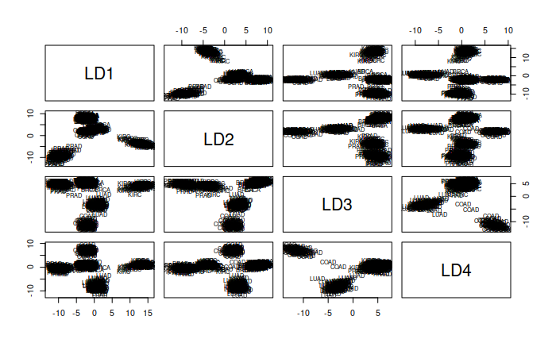

```r
plot(lda_model)

lda.data <- cbind(training_data, predict(lda_model)$x)
library(ggplot2)
```

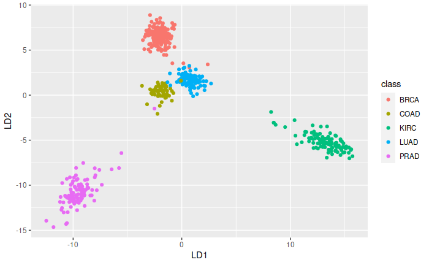

```r
ggplot(lda.data, aes(LD1, LD2)) +
  geom_point(aes(color = class))
```

As we can observe in the results, the accuracy rate of LDA on the testing set is 100 %. It was capable of separating and plot classes on lower dimensions.

**How accurate LDA would be with Cross-Validation method compared to regular LDA?**

### LDA Cross-Validation

```r
lda_model_cross_val <- lda(class~., data = training_data,
                           trControl = trainControl(method = 'cv',
                                                    number = 10,
                                                    verboseIter = TRUE))
```

```
variables are collinear
```

```r
#prediction of test

lda_model_cross_val_predict = predict(lda_model_cross_val, newdata = testing_data)
lda_cv_accuracy <- mean(lda_model_cross_val_predict$class==testing_data$class) #testing accuracy
lda_cv_accuracy
```

```
[1] 1
```

The result from the LDA Cross-Validation method also was very accurate, 100%.

### PCA

Principal Component Analysis (PCA) is a statistical method of reducing the dimensionality of the variables space without loss of information that uses an orthogonal transformation to separate correlated and uncorrelated observations and captures its variability.

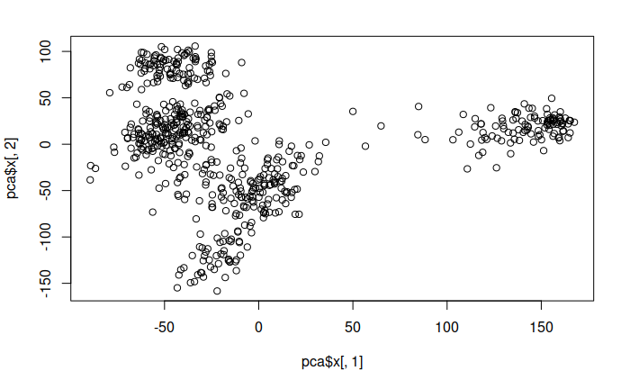

```r
library(MASS)
library(ggplot2)
pca <- prcomp(training_data[-length(training_data)], scale = F)
plot(pca$x[,1], pca$x[,2])
```

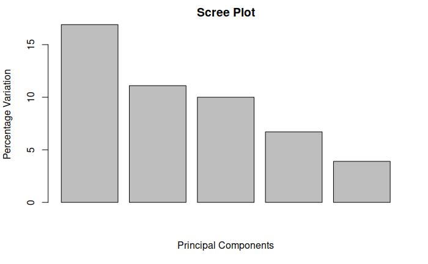

```r
pca.var <- pca$sdev^2 #calculate variation in the data for each PC. if is more than 1 it explains better
pca.var.per <- round(pca.var/sum(pca.var)*100, 1) #percentage of each variation for PC
barplot(pca.var.per[1:5], main = 'Scree Plot', xlab = 'Principal Components', ylab = 'Percentage Variation') #plotting the PC percentage
```

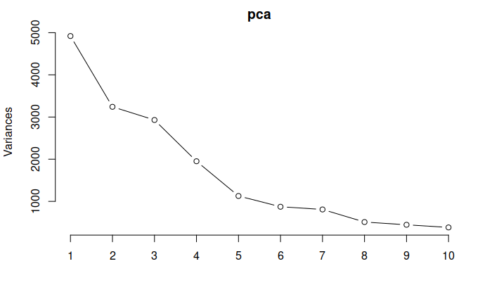

```r
#biplot(pca, scale = 0.5)
plot(pca, type = 'l')
```

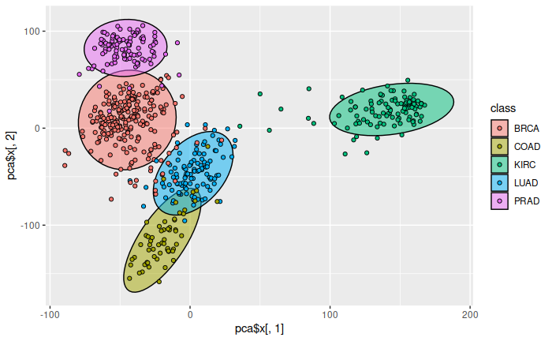

```r
cumvar <- sum(pca.var.per[1:5])
#loading score
ggplot(training_data, aes(pca$x[,1], pca$x[,2], col = class, fill =class))+
  stat_ellipse(geom = 'polygon', col = 'black', alpha = 0.5)+
  geom_point(shape = 21, col = 'black')
```

As a result, we can see, PCA did a good job of clustering cancer diseases. Although five Principal Components were describing less than 50% of data, plotting on PC1 and PC2 gives us a good and clear visualization of all clusters, very comparable with LDA, therefore both LDA and PCA did a decent job in dimension reduction and projecting on 2-dimensional space.

**Which genes have the biggest impact on classification?**

To answer this question, we are going to compare PCA’s top ten loading scores on PC1 and PC2, and the Random Forest method.

### PCA loading scores

```r
for (PC in 1:2){
  component_scores_1 <- names(sort(abs(pca$rotation[,PC]), decreasing = T)[1:10])
  print(PC)
  print(pca$rotation[component_scores_1, PC])
}
```

```
[1] 1
  gene_6733    gene_439   gene_3439   gene_1510  gene_16169  gene_19153
 0.06004454 -0.05992321  0.05925568  0.05628845  0.05583171  0.05430548
 gene_19159  gene_16392   gene_6593  gene_16342
 0.05409174  0.05346500 -0.05334354  0.05240342
[1] 2
  gene_9176   gene_9175   gene_3540   gene_9177   gene_3541   gene_1189
 0.07065700  0.06825173 -0.05827617  0.05348398 -0.05287760 -0.05026268
 gene_11250  gene_17664  gene_19373  gene_11910
 0.04642325  0.04640001 -0.04503048  0.04490796
```

On the table above we can see the top ten genes on each axis that derives into clusters aka types of cancers. On a PC1 axis, genes with positive values push samples to the right hand side, with negative values push to the left hand side. The same logic goes to the PC2 axis, where genes with positive values push samples up, and with negative values push samples down.

For instance, gene_6733 has a positive value, thus samples with high value in this gene are pushed to the right on the PC1 axis. Simultaneously, samples with low values in the very same gene are pushed to the left-hand side on the PC1 axis. Samples with high value in gene_439 are pushed to the left-hand side, and low value is pushed to the right-hand side. The very same idea goes to the PC2 axis but samples are pushed up and down.

### Random Forest

Random forest is yet another powerful method for classification used in machine learning that is especially good for multidimensional data. It uses the idea of Decision Tree classification and applies bootstrapping.

```r
library(randomForest)
random_forest_model <- randomForest(class~., data = training_data, importance = T)
random_forest_model
```

```
Call:
 randomForest(formula = class ~ ., data = training_data, importance = T)
               Type of random forest: classification
                     Number of trees: 500
No. of variables tried at each split: 125

        OOB estimate of  error rate: 0.5%
Confusion matrix:
     BRCA COAD KIRC LUAD PRAD class.error
BRCA  225    0    0    0    0  0.00000000
COAD    0   57    0    1    0  0.01724138
KIRC    0    0  110    0    0  0.00000000
LUAD    2    0    0  104    0  0.01886792
PRAD    0    0    0    0  102  0.00000000
```

```r
#prediction of training set
prediction_forest_train <- predict(random_forest_model, training_data,
                                   type = 'class')
table(prediction_forest_train, training_data$class)
```

```
prediction_forest_train BRCA COAD KIRC LUAD PRAD
                   BRCA  225    0    0    0    0
                   COAD    0   58    0    0    0
                   KIRC    0    0  110    0    0
                   LUAD    0    0    0  106    0
                   PRAD    0    0    0    0  102
```

```r
mean(prediction_forest_train == training_data$class)
```

```
[1] 1
```

```r
#prediction of testing set
prediction_forest_test <- predict(random_forest_model, newdata = testing_data,
                                  type = 'class')
random_forest_accuracy <- mean(prediction_forest_test== testing_data$class) #testing accuracy
random_forest_accuracy
```

```
[1] 1
```

```r
table(prediction_forest_test, testing_data$class)
```

```
prediction_forest_test BRCA COAD KIRC LUAD PRAD
                  BRCA   75    0    0    0    0
                  COAD    0   20    0    0    0
                  KIRC    0    0   36    0    0
                  LUAD    0    0    0   35    0
                  PRAD    0    0    0    0   34
```

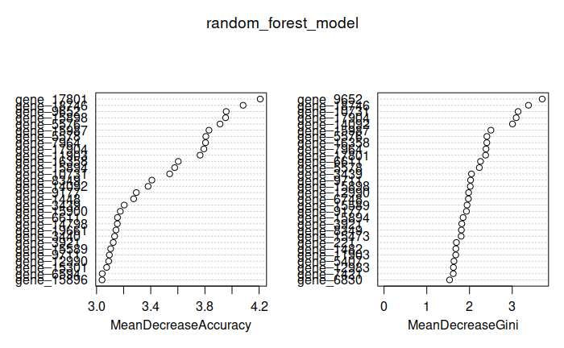

```r
#additional functions
#importance(random_forest_model)
varImpPlot(random_forest_model)
```

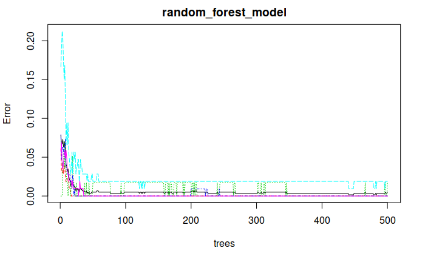

```r
plot(random_forest_model, type="l", main=deparse(substitute(random_forest_model)))
```

The accuracy rate of Random Forest is 100% on testing data, which is remarkable. The random forest method allows us to plot the most important genes for classification. As we can see in the table above (Table MeanDecreaseAccuracy), the most important genes, in general, that help us to classify the type of cancer are listed in there. In another table (Table MeanDecreasedGini), genes that are important in local terms (out of the bag) are listed. MeanDecreaseAccuracy table is more valuable for us since it indicates the most important genes in general that play a significant role in classification.

**How does Decision Tree stand out in comparison with Random Forest, and which are deciding genes in classification for this method?**

To answer those questions, let us run the Decision Tree method.

### Decision Tree

A decision tree classification is another popular method in machine learning. The method splits the dataset into smaller and smaller subsets, and at the same time associated decision trees are developed.

```r
library(rpart)
library(caret)
decision_tree_model <- rpart(class~., data = training_data)
decision_tree_model
```

```
n= 601

node), split, n, loss, yval, (yprob)
      * denotes terminal node

 1) root 601 376 BRCA (0.37 0.097 0.18 0.18 0.17)
   2) gene_18746>=10.72639 218   0 BRCA (1 0 0 0 0) *
   3) gene_18746< 10.72639 383 273 KIRC (0.018 0.15 0.29 0.28 0.27)
     6) gene_12983>=9.061438 111   1 KIRC (0 0 0.99 0.009 0) *
     7) gene_12983< 9.061438 272 167 LUAD (0.026 0.21 0 0.39 0.38)
      14) gene_203< 9.747465 170  65 LUAD (0.041 0.34 0 0.62 0)
        28) gene_3523>=7.627482 58   0 COAD (0 1 0 0 0) *
        29) gene_3523< 7.627482 112   7 LUAD (0.062 0 0 0.94 0)
          58) gene_13631< 8.344572 7   0 BRCA (1 0 0 0 0) *
          59) gene_13631>=8.344572 105   0 LUAD (0 0 0 1 0) *
      15) gene_203>=9.747465 102   0 PRAD (0 0 0 0 1) *
```

```r
#prediction on train data
prediction_decision_train <-predict(decision_tree_model, training_data, type = 'class')
mean(prediction_decision_train==training_data$class)
```

```
[1] 0.9983361
```

```r
confusionMatrix(prediction_decision_train, training_data$class)
```

```
Confusion Matrix and Statistics

          Reference
Prediction BRCA COAD KIRC LUAD PRAD
      BRCA  225    0    0    0    0
      COAD    0   58    0    0    0
      KIRC    0    0  110    1    0
      LUAD    0    0    0  105    0
      PRAD    0    0    0    0  102

Overall Statistics

               Accuracy : 0.9983
                 95% CI : (0.9908, 1)
    No Information Rate : 0.3744
    P-Value [Acc > NIR] : < 2.2e-16

                  Kappa : 0.9978

 Mcnemar's Test P-Value : NA

Statistics by Class:

                     Class: BRCA Class: COAD Class: KIRC Class: LUAD Class: PRAD
Sensitivity               1.0000     1.00000      1.0000      0.9906      1.0000
Specificity               1.0000     1.00000      0.9980      1.0000      1.0000
Pos Pred Value            1.0000     1.00000      0.9910      1.0000      1.0000
Neg Pred Value            1.0000     1.00000      1.0000      0.9980      1.0000
Prevalence                0.3744     0.09651      0.1830      0.1764      0.1697
Detection Rate            0.3744     0.09651      0.1830      0.1747      0.1697
Detection Prevalence      0.3744     0.09651      0.1847      0.1747      0.1697
Balanced Accuracy         1.0000     1.00000      0.9990      0.9953      1.0000
```

```r
#prediction on testing data
prediction_decision_test <-predict(decision_tree_model, newdata = testing_data, type = 'class')
confusionMatrix(prediction_decision_test, testing_data$class)
```

```
Confusion Matrix and Statistics

          Reference
Prediction BRCA COAD KIRC LUAD PRAD
      BRCA   74    0    0    0    1
      COAD    0   19    0    0    0
      KIRC    0    0   36    0    0
      LUAD    1    1    0   35    0
      PRAD    0    0    0    0   33

Overall Statistics

               Accuracy : 0.985
                 95% CI : (0.9568, 0.9969)
    No Information Rate : 0.375
    P-Value [Acc > NIR] : < 2.2e-16

                  Kappa : 0.9802

 Mcnemar's Test P-Value : NA

Statistics by Class:

                     Class: BRCA Class: COAD Class: KIRC Class: LUAD Class: PRAD
Sensitivity               0.9867      0.9500        1.00      1.0000      0.9706
Specificity               0.9920      1.0000        1.00      0.9879      1.0000
Pos Pred Value            0.9867      1.0000        1.00      0.9459      1.0000
Neg Pred Value            0.9920      0.9945        1.00      1.0000      0.9940
Prevalence                0.3750      0.1000        0.18      0.1750      0.1700
Detection Rate            0.3700      0.0950        0.18      0.1750      0.1650
Detection Prevalence      0.3750      0.0950        0.18      0.1850      0.1650
Balanced Accuracy         0.9893      0.9750        1.00      0.9939      0.9853
```

```r
decision_tree_accuracy <- mean(prediction_decision_test==testing_data$class) #testing accuracy
decision_tree_accuracy
```

```
[1] 0.985
```

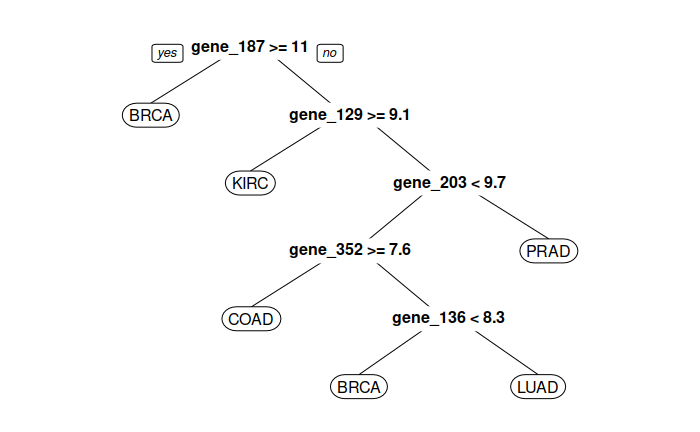

```r
library(rpart.plot)
prp(decision_tree_model)
```

**How accurate was the PCA method and how does it stand out with another unsupervised clustering method as k-means?**

To answer these questions, first of all, we have to measure the accuracy of PCA, and in order to do that, Multinomial Logistic Regression is used in this analysis. Afterward, we are going to run k-means clustering.

### Multinomial Logistic Regression

Multinomial Logistic Regression (MLR) is a predictive regression analysis for a dependent variable with more than 2 levels. In this analysis, MLR is used to test the accuracy of PCA.

```r
#preparation for MLR
pca_train <- predict(pca, training_data)
pca_train <- data.frame(pca_train, training_data$class)

pca_test <- predict(pca, testing_data)
pca_test <- data.frame(pca_test, testing_data$class)


#multinom reg

library(nnet)
pca_train$training_data.class <- relevel(pca_train$training_data.class,
                                             ref = 'BRCA')
mnom_model <- multinom(training_data.class~PC1+PC2, data = pca_train)
#testing on train
pca_predict_train <- predict(mnom_model, pca_train)
mean(pca_predict_train==pca_train$training_data.class)
```

```
[1] 0.9567388
```

```r
#testing on test
pca_predict_test = predict(mnom_model, newdata = pca_test)
mnom_accuracy <- mean(pca_predict_test==pca_test$testing_data.class)
mnom_accuracy
```

```
[1] 0.945
```

MLR was run on PC1 and PC2, since these components have highest variation. The accuracy on the testing set is very high. As a reference type, BRCA was indicated for this analysis. We can indicate any other type of cancer. We can conclude that the accuracy rate of PCA was very high.

### K-means clustering

K-means clustering is an unsupervised learning method, where k is a number of clusters (cluster centroids) indicated initially. The method does clustering based on the distance to the centroid clusters.

```r
library(ggfortify)
set.seed(123)
k_means_clust <- kmeans(data_snapshot[-length(data_snapshot)], 5, nstart =25)
lev <- as.factor(c('COAD', 'KIRC', 'BRCA', 'PRAD', 'LUAD'))
lev <- factor(lev, levels = c('COAD', 'KIRC', 'BRCA', 'PRAD', 'LUAD'))


k_means_cluster_vector <- factor(c(k_means_clust[1]$cluster), labels = lev)

table(data_snapshot$class, k_means_cluster_vector)
```

```
      k_means_cluster_vector
       COAD KIRC BRCA PRAD LUAD
  BRCA    0    0  300    0    0
  COAD   74    0    0    0    4
  KIRC    0  145    1    0    0
  LUAD    0    0    2    0  139
  PRAD    0    0    0  136    0
```

```r
k_mean_accuracy <- mean(k_means_cluster_vector==data_snapshot$class) #testing accuracy
k_mean_accuracy
```

```
[1] 0.9912609
```

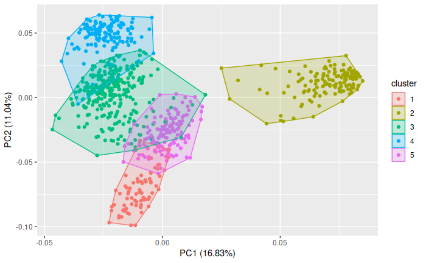

```r
autoplot(k_means_clust, data_snapshot, frame= T)
```

Levels for K-means were assigned according to PCA’s ordering level. As we can see in the plot above, clusters founded by k-means are similar to PCA’s clusters and the overall accuracy of k-means is very high, even higher than PCA’s one.

**How does Support Vector Machine, optimization classification method that does not make any assumptions on the distribution of types of cancer stand out in comparison with other classification methods such as LDA or MRL in terms of accuracy and performance in general?**

### Support Vector Machine

A support vector machine (SVM) is a supervised learning method perfectly suitable for classification and regression analysis.

```r
library(e1071)
svm_classificator = svm(formula = class~.,
                        data = training_data,
                        type = 'C-classification',
                        kernel = 'radial',
                        cost = 1)
#prediction on training set
prediction_svm_classif_train = predict(svm_classificator, training_data)
table(prediction_svm_classif_train, training_data$class)
```

```
prediction_svm_classif_train BRCA COAD KIRC LUAD PRAD
                        BRCA  225    0    0    0    0
                        COAD    0   58    0    0    0
                        KIRC    0    0  110    0    0
                        LUAD    0    0    0  106    0
                        PRAD    0    0    0    0  102
```

```r
mean(prediction_svm_classif_train==training_data$class)
```

```
[1] 1
```

```r
#prediction of test data
prediction_svm_classif_test = predict(svm_classificator, newdata = testing_data)
table(prediction_svm_classif_test, testing_data$class)
```

```
prediction_svm_classif_test BRCA COAD KIRC LUAD PRAD
                       BRCA   75    0    0    1    2
                       COAD    0   20    0    0    0
                       KIRC    0    0   36    0    0
                       LUAD    0    0    0   34    0
                       PRAD    0    0    0    0   32
```

```r
svm_accuracy <- mean(prediction_svm_classif_test==testing_data$class) #testing accuracy
svm_accuracy
```

```
[1] 0.985
```

SVM was done on the “Radial” kernel, which is good for a multidimensional dataset as we have here. Cost value, which is responsible for bias-variance tradeoff was fixed to a value equal 1. With a higher value of cost, a hyperplane would be ‘flexible’, and with lower value, hyperplane would be ‘flatter’. The accuracy rate on the testing set was very high.

**How accurate will SVM with K-Fold Validation be?**

### SVM K-Fold Validation

```r
library(caret)

folds = createFolds(training_data$class, k = 10)

cv = lapply(folds, function(x){
  training_fold = training_data[-x,]
  test_fold = training_data[x,]

  classificator = svm(formula = class~.,
                      data = training_fold,
                      type = 'C-classification',
                      kernel = 'radial',
                      cost = 0.1)
  y_predict = predict(classificator, newdata = test_fold[-length(testing_data)])
  cm = table(y_predict, test_fold[,length(test_fold)])
  return(mean(y_predict==test_fold[,length(test_fold)]))
})
k_fold_accuracy = mean(as.numeric(cv))
k_fold_accuracy #testing accuracy
```

```
[1] 0.901568
```

## **Conclusion**

In a table below, there are accuracy rates of used methods. As we can see in the results, all methods did a decent job in classification and clustering 5 types of cancer. We also found out the most important genes, the role of which is significant in the determination of cancer type, and we can observe it in the decision tree, random forest, and PCA’s loading scores. PCA and LDA were perfect for in dimensionality reduction for this dataset as we can see in the plots. In general, all performed analyses were good in achieving the initial aim of the paper.

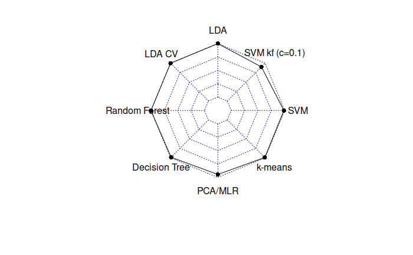

| Method | Accuracy_percent |
| --- | --- |
| LDA | 100.0 |
| LDA CV | 100.0 |
| Random Forest | 100.0 |
| Decision Tree | 98.5 |
| PCA/MLR | 94.5 |
| k-means | 99.1 |
| SVM | 98.5 |
| SVM kf (c=0.1) | 90.2 |